# RNA-seq Tutorial

Yihan Wu

February 14, 2019

# Introduction

> Note: Installation of packages may take several minutes.

See transcriptomics presentation

A typical transcriptome analysis will begin with raw sequences that must be processed and aligned to a reference genome. This is typically done on a high-performance computer, so we will start with our aligned sequences for this tutorial.

Transcriptome sequencing is very often used to compare expression profiles across samples, under the reasonable assumption that the number of reads (sequences) is proportional to the abundance of RNA in the initial sample. Thus, we can identify genes that are upregulated (higher abundance) or downregulated (lower abundance) relative to a control or other reference sample(s). This comparison is called a **differential expression** analysis.

For example, we might compare genes or isoforms in different experimental treatments or test groups. In addition to comparing two samples, we can also look at changes in gene expression over time. Examples might include expression profiling to identify how genes differ among samples or respond to different external stimula. For example:

- genes involved in cancer progression
- plants responses to drought, herbivory, or other stresses
- genes affected by a knockout mutation

## Differential Expression Analysis

1. Extract RNA from a sample
2. Enrich for sequences of interest (e.g. ribosome depletion)
3. Synthesize cDNA (coding DNA) from RNA using [reverse transcriptase](https://en.wikipedia.org/wiki/Reverse_transcriptase)
4. Align reads to a reference genome
5. Count the number of reads in genic regions (i.e. parts of the genome with annotated genes)
6. Perform statistical tests comparing read “counts” for differential expression between samples

There are multiple tools for analysis of RNA expression data such as the Tuxedo pipeline covered in this tutorial, which requires a reference genome.

Programs such as kallisto and [salmon](https://combine-lab.github.io/salmon/) need prior transcriptome asssemblies, but are extremely fast.

Other pipelines like [Trinity](https://github.com/trinityrnaseq/trinityrnaseq/wiki) do not need a reference genome or a priori transcriptome information.

Steps 1 to 4 are not coverd in this tutorial. Instead we will focus on counting and visualizing differentially expressed genes using DESeq2. Most of the material is taken from the DESeq2 vignette. If you are interested in learning about the upstream sequence processing, see this [Colautti Lab alignment tutorial](http://post.queensu.ca/~rc91/NGS/TuxedoTutorial.html).

# Downloading and examining data

> NOTE: When asked to update all/some/none? [a/s/n] choose: n

```r
BiocManager::install("IRanges")
# Main analysis
BiocManager::install("DESeq2")
# for heatmap visualization
BiocManager::install("pheatmap")
# for GO analysis
BiocManager::install("org.Hs.eg.db")
```

```r
library(DESeq2)
```

We will be using a prepared dataset from [Recount](http://bowtie-bio.sourceforge.net/recount/) containing RNAseq data on human liver transcriptomes. We will be using this data to compare expression profiles between human males and females. The source paper for this data is [Blekman et al. 2010](https://www.ncbi.nlm.nih.gov/pubmed?term=20009012)

The counts and treatment information is all included in the RData file as an `ExpressionSet` object – a class of object in R created by the `ExpressionSet()` function.

Make a new project and create a folder called `Data`. Then, download the file and savit it to the `Data` folder in your local working directory. This data is an *S4 object*, so we import it with the `load` function – this is the equivalent of `read.csv` for a *data.frame* object.

```r
load("Data/gilad_eset.RData")
```

Note that we aren’t assigning an object in this case. However, something was added to our R environment. We can use the `ls()` function to see:

```r
ls()
```

```
## [1] "gilad.eset"
```

We can also look in the ‘Environment’ tab in R Studio.

Let’s take a look at the structure:

```r
str(gilad.eset)
```

```
## Formal class 'ExpressionSet' [package "Biobase"] with 7 slots
##   ..@ experimentData   :Formal class 'MIAME' [package "Biobase"] with 13 slots
##   .. .. ..@ name             : chr ""
##   .. .. ..@ lab              : chr ""
##   .. .. ..@ contact          : chr ""
##   .. .. ..@ title            : chr ""
##   .. .. ..@ abstract         : chr ""
##   .. .. ..@ url              : chr ""
##   .. .. ..@ pubMedIds        : chr ""
##   .. .. ..@ samples          : list()
##   .. .. ..@ hybridizations   : list()
##   .. .. ..@ normControls     : list()
##   .. .. ..@ preprocessing    : list()
##   .. .. ..@ other            : list()
##   .. .. ..@ .__classVersion__:Formal class 'Versions' [package "Biobase"] with 1 slot
##   .. .. .. .. ..@ .Data:List of 2
##   .. .. .. .. .. ..$ : int [1:3] 1 0 0
##   .. .. .. .. .. ..$ : int [1:3] 1 1 0
##   ..@ assayData        :<environment: 0x00000000259e6ea0>
##   ..@ phenoData        :Formal class 'AnnotatedDataFrame' [package "Biobase"] with 4 slots
##   .. .. ..@ varMetadata      :'data.frame':  3 obs. of  1 variable:
##   .. .. .. ..$ labelDescription: chr [1:3] NA NA NA
##   .. .. ..@ data             :'data.frame':  6 obs. of  3 variables:
##   .. .. .. ..$ sample.id    : Factor w/ 6 levels "SRX014818and9",..: 1 2 3 4 5 6
##   .. .. .. ..$ num.tech.reps: num [1:6] 2 2 2 2 2 2
##   .. .. .. ..$ gender       : Factor w/ 2 levels "F","M": 1 1 1 2 2 2
##   .. .. ..@ dimLabels        : chr [1:2] "sampleNames" "sampleColumns"
##   .. .. ..@ .__classVersion__:Formal class 'Versions' [package "Biobase"] with 1 slot
##   .. .. .. .. ..@ .Data:List of 1
##   .. .. .. .. .. ..$ : int [1:3] 1 1 0
##   ..@ featureData      :Formal class 'AnnotatedDataFrame' [package "Biobase"] with 4 slots
##   .. .. ..@ varMetadata      :'data.frame':  1 obs. of  1 variable:
##   .. .. .. ..$ labelDescription: chr NA
##   .. .. ..@ data             :'data.frame':  52580 obs. of  1 variable:
##   .. .. .. ..$ gene: Factor w/ 52580 levels "ENSG00000000003",..: 1 2 3 4 5 6 7 8 9 10 ...
##   .. .. ..@ dimLabels        : chr [1:2] "featureNames" "featureColumns"
##   .. .. ..@ .__classVersion__:Formal class 'Versions' [package "Biobase"] with 1 slot
##   .. .. .. .. ..@ .Data:List of 1
##   .. .. .. .. .. ..$ : int [1:3] 1 1 0
##   ..@ annotation       : chr(0)
##   ..@ protocolData     :Formal class 'AnnotatedDataFrame' [package "Biobase"] with 4 slots
##   .. .. ..@ varMetadata      :'data.frame':  0 obs. of  1 variable:
##   .. .. .. ..$ labelDescription: chr(0)
##   .. .. ..@ data             :'data.frame':  6 obs. of  0 variables
##   .. .. ..@ dimLabels        : chr [1:2] "sampleNames" "sampleColumns"
##   .. .. ..@ .__classVersion__:Formal class 'Versions' [package "Biobase"] with 1 slot
##   .. .. .. .. ..@ .Data:List of 1
##   .. .. .. .. .. ..$ : int [1:3] 1 1 0
##   ..@ .__classVersion__:Formal class 'Versions' [package "Biobase"] with 1 slot
##   .. .. ..@ .Data:List of 4
##   .. .. .. ..$ : int [1:3] 2 13 0
##   .. .. .. ..$ : int [1:3] 2 12 1
##   .. .. .. ..$ : int [1:3] 1 3 0
##   .. .. .. ..$ : int [1:3] 1 0 0
```

Alternatively, click the litle bubble next to `gilad.eset` in the ‘Environment’ tab. Note the large file size – why do you think it’s so big (what are the main data stored here)?

All the different slots beginning with `@` contain information about the experiment. You can access many (but not all) of these directly by applying the name as a function. For example, look for `@phenoData`, which has a subslot called `@dimLabels`, which itself has two levels: `sampleNames` and `sampleColumns`. Try running these as functions:

```r
phenoData(gilad.eset)
```

```
## An object of class 'AnnotatedDataFrame'
##   sampleNames: SRX014818and9 SRX014820and1 ... SRX014828and9 (6
##     total)
##   varLabels: sample.id num.tech.reps gender
##   varMetadata: labelDescription
```

```r
dimLabels(gilad.eset)
```

[output not shown]

```r
sampleNames(gilad.eset)
```

```
## [1] "SRX014818and9" "SRX014820and1" "SRX014822and3" "SRX014824and5"
## [5] "SRX014826and7" "SRX014828and9"
```

This contains the names of our samples, but what do these names mean? The SRX code suggests it’s a short-read sequence dataset, but why are there two numbers (e.g. SRX01418and9). Some details in the paper might give us a hint.

We can also find the experimental data in the `phenoData` slot.

```r
pData(gilad.eset)
```

```
##                   sample.id num.tech.reps gender
## SRX014818and9 SRX014818and9             2      F
## SRX014820and1 SRX014820and1             2      F
## SRX014822and3 SRX014822and3             2      F
## SRX014824and5 SRX014824and5             2      M
## SRX014826and7 SRX014826and7             2      M
## SRX014828and9 SRX014828and9             2      M
```

Note that each sample has a number 2 for the column called ‘num.tech.reps’. This is probably the number of technical replicates, which means that the same sample was prepared twice, and then pooled (mixed together) before sequencing.

Note also that the first three samples are females and the last three are males.

The transcript counts can be viewed with `exprs`.

```r
head(exprs(gilad.eset))
```

```
##                 SRX014818and9 SRX014820and1 SRX014822and3 SRX014824and5
## ENSG00000000003            60            60            16             9
## ENSG00000000005             0             0             0             0
## ENSG00000000419            25             9            15            15
## ENSG00000000457            32            19            21            31
## ENSG00000000460             1             3             0             5
## ENSG00000000938             6             7             8             4
##                 SRX014826and7 SRX014828and9
## ENSG00000000003            56            37
## ENSG00000000005             0             0
## ENSG00000000419            26            11
## ENSG00000000457            28            28
## ENSG00000000460             1             1
## ENSG00000000938             4             1
```

> What does each column represent? What about each row?

# DESeq2 analysis

To analyze and graph the data using the `DESeq2` package, we have to change the data format from an `ExpressionSet` to a `DESeqDataSet` object and identify the factor in the experimental design that we want to compare for our differential expression analysis. This requires a few steps.

First, convert the `ExpressionSet` to a `SummarizedExperiment`

```r
expr_se <- SummarizedExperiment(exprs(gilad.eset))
head(expr_se)
```

```
## class: SummarizedExperiment
## dim: 6 6
## metadata(0):
## assays(1): ''
## rownames(6): ENSG00000000003 ENSG00000000005 ... ENSG00000000460
##   ENSG00000000938
## rowData names(0):
## colnames(6): SRX014818and9 SRX014820and1 ... SRX014826and7
##   SRX014828and9
## colData names(0):
```

Second, we associate the count data with each of the treatments based on the sample.id:

```r
colData(expr_se) <- DataFrame(pData(gilad.eset))
```

Third, convert from `SummarizedExperiment` to `DESeq`

```r
expr_de <- DESeqDataSet(expr_se, design = ~ gender)
```

```
## renaming the first element in assays to 'counts'
```

Note: it is also possible to use design = ~1 above and set the design afterwards with design(expr_de). This could be useful if you had different comparisons you wanted to make on the same data.

Finally, we are ready to analyze the data by running the `DESeq` function on the `DESeqDataSet` object. The model below will take a few seconds to run. The details of this analysis are a bit complicated, but worth reading in detail if you want to do this for a project or publication (use `?DESeq` and look up the references therein).

The analysis is complicated because sequencing is essentially a process of random sampling, so two genes may look like they are differentially expressed between two samples just because one sample has more overall RNA or because one sample has another gene ‘hogging’ all the sequence reads. So it’s not possible to compare one gene across samples without also considering all the other genes in those samples.

```r
de_results <- DESeq(expr_de)
```

Once the analysis is done, we can extract a table of results using the `results()` function. This is useful for other downstream analyses including visualization.

```r
DEdat <- results(de_results)
head(DEdat)
```

```
## log2 fold change (MLE): gender M vs F
## Wald test p-value: gender M vs F
## DataFrame with 6 rows and 6 columns
##                         baseMean      log2FoldChange             lfcSE
##                        <numeric>           <numeric>         <numeric>
## ENSG00000000003 38.4861655660068  -0.636080405143175   0.6338736763103
## ENSG00000000005                0                  NA                NA
## ENSG00000000419  16.531492591005 -0.0459820068355181 0.609659174149594
## ENSG00000000457 26.4013679241789     0.1718183111848 0.476002672833249
## ENSG00000000460 1.95259420862927   0.805281830848979  1.60261038773118
## ENSG00000000938 5.09740492589779     -1.324866931362 0.943224228567802
##                                stat            pvalue             padj
##                           <numeric>         <numeric>        <numeric>
## ENSG00000000003   -1.00348133849905 0.315628676476054 0.99997903848561
## ENSG00000000005                  NA                NA               NA
## ENSG00000000419 -0.0754224799448935 0.939878573738684 0.99997903848561
## ENSG00000000457    0.36096081175786 0.718128742512602 0.99997903848561
## ENSG00000000460   0.502481349811428 0.615328968180959 0.99997903848561
## ENSG00000000938   -1.40461503345148  0.16013578379046 0.99997903848561
```

We can select the genes that are most different between samples from the DESeq2 results above and investigate their function. For example, genes with **padj** less than 10%.

```r
DE_list <- subset(DEdat, padj < 0.1)
DE_list
```

```
## log2 fold change (MLE): gender M vs F
## Wald test p-value: gender M vs F
## DataFrame with 4 rows and 6 columns
##                         baseMean    log2FoldChange             lfcSE
##                        <numeric>         <numeric>         <numeric>
## ENSG00000049239  610.15410116007  1.48873274180955 0.314138613529478
## ENSG00000110244 252.915548249407 -2.32420844706005 0.541939365028577
## ENSG00000143546 192.604210422822  -3.0667559246525 0.703937091501114
## ENSG00000244734 94.9769083984912  -2.9350691228982 0.704277431397419
##                              stat               pvalue               padj
##                         <numeric>            <numeric>          <numeric>
## ENSG00000049239  4.73909502904789 2.14674816076066e-06 0.0225794971548806
## ENSG00000110244 -4.28868725366997 1.79732237088683e-05 0.0630141223232922
## ENSG00000143546 -4.35657669084148 1.32112417442602e-05 0.0630141223232922
## ENSG00000244734 -4.16748995786288 3.07972075559841e-05 0.0809812572684602
```

To figure out what genes these are, we need the annotated reference genome. Genomic annotations on model organisms like humans have been prepared and packaged for R so they can be easily downloaded from Bioconductor.

```r
library(org.Hs.eg.db)
geneinfo <- AnnotationDbi::select(org.Hs.eg.db, keys=rownames(DE_list),
                   columns=c("ENSEMBL","SYMBOL","GENENAME"),
                   keytype="ENSEMBL")
geneinfo
```

```
##           ENSEMBL SYMBOL
## 1 ENSG00000049239   H6PD
## 2 ENSG00000110244  APOA4
## 3 ENSG00000143546 S100A8
## 4 ENSG00000244734    HBB
##                                                   GENENAME
## 1 hexose-6-phosphate dehydrogenase/glucose 1-dehydrogenase
## 2                                        apolipoprotein A4
## 3                          S100 calcium binding protein A8
## 4                                  hemoglobin subunit beta
```

**Gene Ontology** or **GO** is a system for classifying genes by their function. A GO analysis can be used to discover which groups or types of genes are differentially expressed. A GO analysis in R can be performed using the `topGO` or `goseq` packages.

# Visualization

## MA Plot

We can visualize the log-fold change in expression with a MA plot. An MA plot compares the log-ratio (or log-fold change or M) to the average normalized reads.

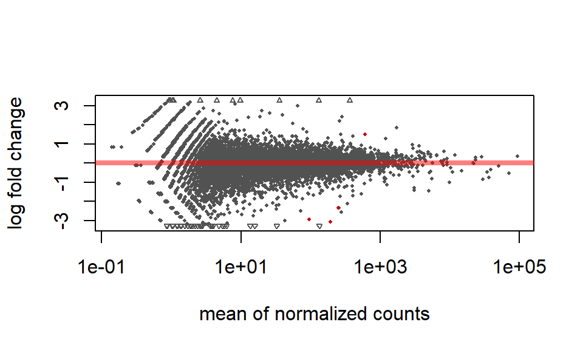

```r
plotMA(DEdat)
```

## Heatmap

We can visualize differential expression across samples with a heatmap.

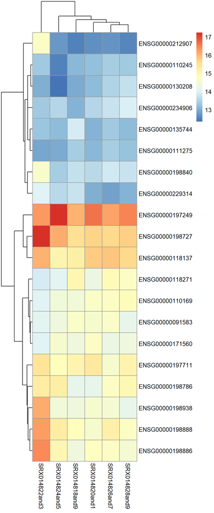

```r
library(pheatmap)
# need transformed values
vsd <- vst(de_results, blind=FALSE) # Variance stabilizing transformation
rld <- rlog(de_results, blind=FALSE) # Controls for rows with few counts
ntd <- normTransform(de_results) # Transforms data for plotting
top20 <- order(rowMeans(counts(de_results,normalized=TRUE)),
                decreasing=TRUE)[1:20] # Average counts for each gene and Select top 20 most abundant genes
pheatmap(assay(ntd)[top20,])
```

Note how the samples and genes are clusted by similar expression profiles, similar to the metabarcoding tutorial.

We can also add extra annotation on the plot for the treatments, in this case gender.

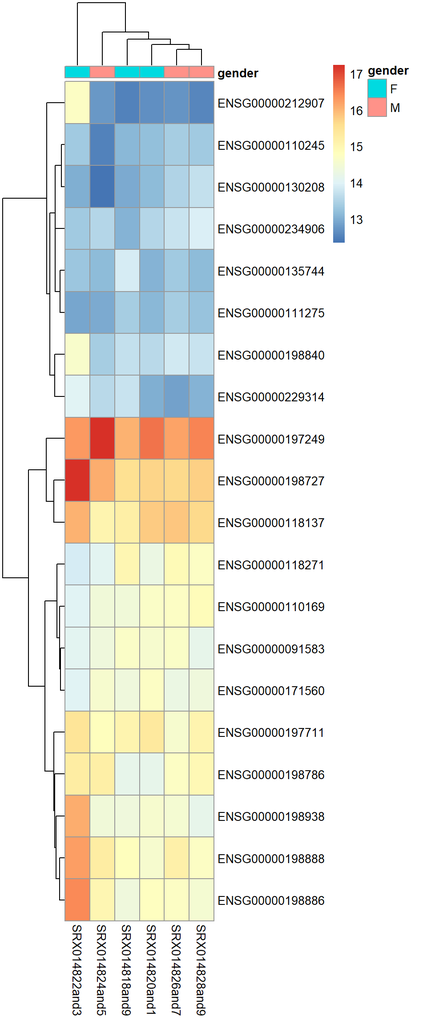

```r
annot_df <- data.frame(gender = colData(expr_se)$gender, row.names = row.names(colData(expr_se)))

pheatmap(assay(ntd)[top20,], annotation_col = annot_df)
```

## PCA Plot

We can also use a PCA in ggplot2 to look at how similar samples are to each other. This is similar in principal to the NMDS analysis we did in the metabarcoding tutorial.

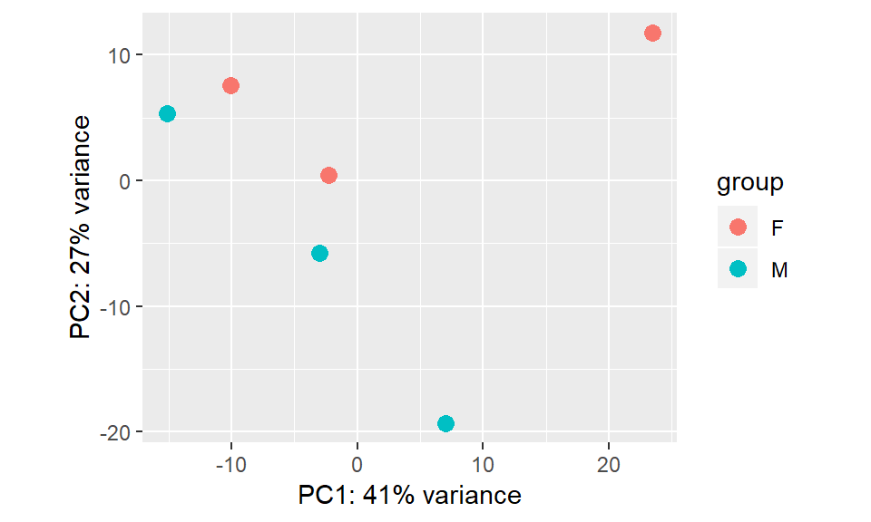

```r
plotPCA(vsd, intgroup="gender")
```

That looks suspiciously like a ggplot2 formatted graph. Let’s try modifying it with a ggplot layer:

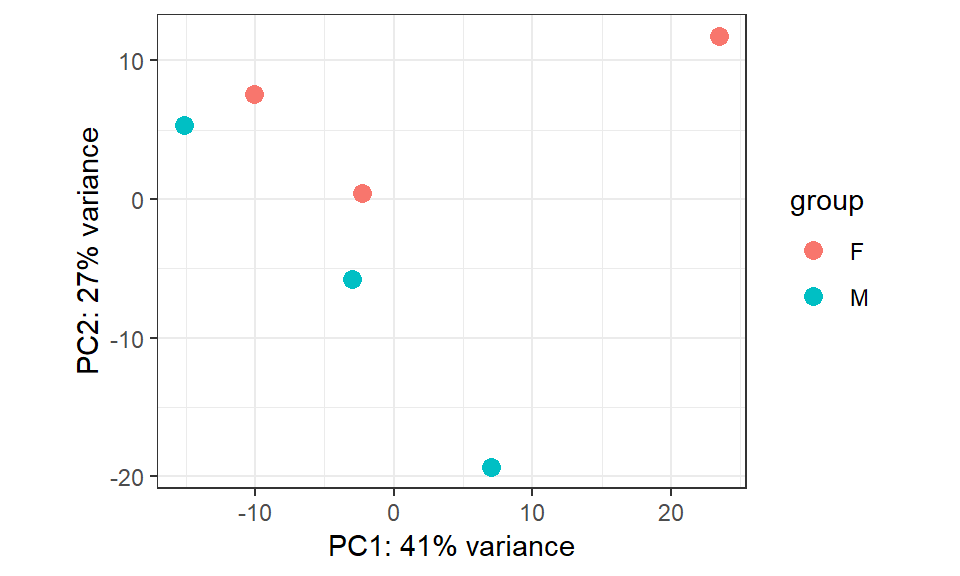

```r
library(ggplot2)
plotPCA(vsd, intgroup="gender") + theme_bw()
```